## MSBR 70200: In-class Exercise Hypothesis Testing

Name: Skye Liu

### 1. Advertising Agency

An advertising agency has been hired by a network to determine an optimal balance of commercials for its daytime soap opera audience. The agency has designed a plan under the assumption that 80% of its audience are women. The agency would consider reworking its plan if the proportion of women is significantly lower than 80%.

Use `advertising` dataset after loading `advertising.rda`

#### 1-1. Write your hypothesis

- The null hypothesis: proportion of women >= 0.8
- The alternative hypothesis: proportion of women < 0.8

#### 1-2. Hypothesis Testing R Code and Result

```r
load("advertising.rda")
result <- single_prop(
  advertising,
  var = "gender",
  lev = "female",
  comp_value = 0.8,
  alternative = "less"
)
summary(result)
```

```
Single proportion test (binomial exact)
Data      : advertising
Variable  : gender
Level     : female in gender
Confidence: 0.95
Null hyp. : the proportion of female in gender = 0.8
Alt. hyp. : the proportion of female in gender < 0.8

     p  ns   n n_missing    sd    se    me
 0.730 292 400         0 0.444 0.022 0.044

   diff  ns p.value    0%   95%
 -0.070 292  < .001 0.000 0.766 ***

Signif. codes:  0 '***' 0.001 '**' 0.01 '*' 0.05 '.' 0.1 ' ' 1
```

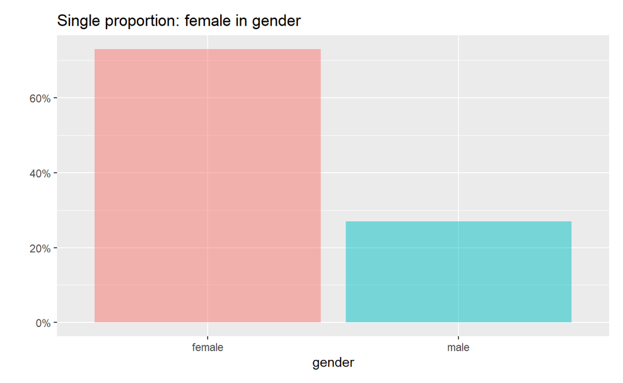

```r
plot(result, plots = "bar", custom = FALSE)
```

As the P value is 0.001 < 0.05, the null hypothesis should be rejected, which means the proportion of women is < 0.8.

### 2. Diamond Price

We want to test if the population mean of diamond price is $4,000.

Use `diamonds` dataset.

#### 2-1. Write your hypothesis

- The null hypothesis: diamond price = 4,000
- The alternative hypothesis: diamond price != 4,000

#### 2-2. Hypothesis Testing R Code and Result

```r
result <- single_mean(
  diamonds,
  var = "price",
  comp_value = 4000
)
summary(result)
```

```
Single mean test
Data      : diamonds
Variable  : price
Confidence: 0.95
Null hyp. : the mean of price = 4000
Alt. hyp. : the mean of price is not equal to 4000

      mean     n n_missing        sd     se      me
 3,907.186 3,000         0 3,956.915 72.243 141.651

    diff     se t.value p.value   df     2.5%    97.5%
 -92.814 72.243  -1.285   0.199 2999 3765.535 4048.837

Signif. codes:  0 '***' 0.001 '**' 0.01 '*' 0.05 '.' 0.1 ' ' 1
```

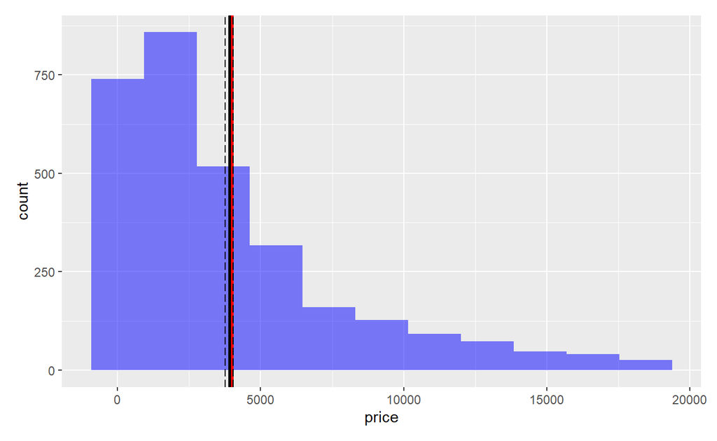

```r
plot(result, plots = "hist", custom = FALSE)
```

### 3. Diamond Price per Cut

We want to test if the ‘fair’ cut diamond price is different from the ‘premium’ cut diamond price.

Use `diamonds` dataset.

#### 3-1. Write your hypothesis

- The null hypothesis: ‘fair’ cut diamond price - ‘premium’ cut diamond price = 0
- The alternative hypothesis: ‘fair’ cut diamond price - ‘premium’ cut diamond price != 0

#### 3-2. Hypothesis Testing R Code and Result

```r
result <- compare_means(
  diamonds,
  var1 = "cut",
  var2 = "price",
  comb = "Fair:Premium"
)
summary(result, show = FALSE)
```

```
Pairwise mean comparisons (t-test)
Data      : diamonds
Variables : cut, price
Samples   : independent
Confidence: 0.95
Adjustment: None

       cut      mean     n n_missing        sd      se      me
      Fair 4,505.238   101         0 3,749.540 373.093 740.206
      Good 4,130.433   275         0 3,730.354 224.949 442.848
 Very Good 3,959.916   677         0 3,895.899 149.732 293.995
   Premium 4,369.409   771         0 4,236.977 152.591 299.544
     Ideal 3,470.224 1,176         0 3,827.423 111.610 218.977

 Null hyp.        Alt. hyp.                   diff    p.value
 Fair = Premium   Fair not equal to Premium   135.829 0.737

Signif. codes:  0 '***' 0.001 '**' 0.01 '*' 0.05 '.' 0.1 ' ' 1
```

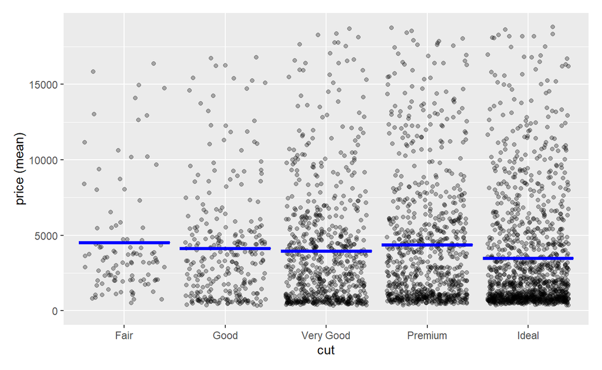

```r
plot(result, plots = "scatter", custom = FALSE)
```